# PROJECT 3 COUNTRY GDP ANALYSIS PANDAS SEABORN

```python
import pandas as pd # It is used for Dataframe
```

```python
import numpy as np # It is used for Mutli-Dimentional Array
```

## To Read the Dataset

```python
gdp = pd.read_csv(r'C:\Users\Shriniwas\Desktop\Data Analyst Course\11. 16_Nov_2024\15th,16th matplotlib\DataFrame_ Pandas\data.csv')
```

## head() returns the first n rows of a Pandas DataFrame or Series.

- By default, it returns the first 5 rows of the DataFrame.
- Customize the number of rows returned by passing an integer to the method.

```python
gdp.head()
```

|  | CountryName | CountryCode | BirthRate | InternetUsers | IncomeGroup |
| --- | --- | --- | --- | --- | --- |
| 0 | Aruba | ABW | 10.244 | 78.9 | High income |
| 1 | Afghanistan | AFG | 35.253 | 5.9 | Low income |
| 2 | Angola | AGO | 45.985 | 19.1 | Upper middle income |
| 3 | Albania | ALB | 12.877 | 57.2 | Upper middle income |
| 4 | United Arab Emirates | ARE | 11.044 | 88.0 | High income |

```python
gdp.head(1)
```

|  | CountryName | CountryCode | BirthRate | InternetUsers | IncomeGroup |
| --- | --- | --- | --- | --- | --- |
| 0 | Aruba | ABW | 10.244 | 78.9 | High income |

```python
gdp.head(10)
```

|  | CountryName | CountryCode | BirthRate | InternetUsers | IncomeGroup |
| --- | --- | --- | --- | --- | --- |
| 0 | Aruba | ABW | 10.244 | 78.9000 | High income |
| 1 | Afghanistan | AFG | 35.253 | 5.9000 | Low income |
| 2 | Angola | AGO | 45.985 | 19.1000 | Upper middle income |
| 3 | Albania | ALB | 12.877 | 57.2000 | Upper middle income |
| 4 | United Arab Emirates | ARE | 11.044 | 88.0000 | High income |
| 5 | Argentina | ARG | 17.716 | 59.9000 | High income |
| 6 | Armenia | ARM | 13.308 | 41.9000 | Lower middle income |
| 7 | Antigua and Barbuda | ATG | 16.447 | 63.4000 | High income |
| 8 | Australia | AUS | 13.200 | 83.0000 | High income |
| 9 | Austria | AUT | 9.400 | 80.6188 | High income |

```python
gdp.head(100)
```

|  | CountryName | CountryCode | BirthRate | InternetUsers | IncomeGroup |
| --- | --- | --- | --- | --- | --- |
| 0 | Aruba | ABW | 10.244 | 78.90 | High income |
| 1 | Afghanistan | AFG | 35.253 | 5.90 | Low income |
| 2 | Angola | AGO | 45.985 | 19.10 | Upper middle income |
| 3 | Albania | ALB | 12.877 | 57.20 | Upper middle income |
| 4 | United Arab Emirates | ARE | 11.044 | 88.00 | High income |
| ... | ... | ... | ... | ... | ... |
| 95 | Korea, Rep. | KOR | 8.600 | 84.77 | High income |
| 96 | Kuwait | KWT | 20.575 | 75.46 | High income |
| 97 | Lao PDR | LAO | 27.051 | 12.50 | Lower middle income |
| 98 | Lebanon | LBN | 13.426 | 70.50 | Upper middle income |
| 99 | Liberia | LBR | 35.521 | 3.20 | Low income |

100 rows × 5 columns

```python
gdp.head(0)
```

|  | CountryName | CountryCode | BirthRate | InternetUsers | IncomeGroup |
| --- | --- | --- | --- | --- | --- |

## tail() is a convenient method in Pandas for quickly viewing the last few rows of your dataset.

- It helps in inspecting the data towards the end, which is particularly useful when you're dealing with time series data or datasets that are sorted in a particular order.

```python
gdp.tail()
```

|  | CountryName | CountryCode | BirthRate | InternetUsers | IncomeGroup |
| --- | --- | --- | --- | --- | --- |
| 190 | Yemen, Rep. | YEM | 32.947 | 20.0 | Lower middle income |
| 191 | South Africa | ZAF | 20.850 | 46.5 | Upper middle income |
| 192 | Congo, Dem. Rep. | COD | 42.394 | 2.2 | Low income |
| 193 | Zambia | ZMB | 40.471 | 15.4 | Lower middle income |
| 194 | Zimbabwe | ZWE | 35.715 | 18.5 | Low income |

```python
gdp.tail(2)
```

|  | CountryName | CountryCode | BirthRate | InternetUsers | IncomeGroup |
| --- | --- | --- | --- | --- | --- |
| 193 | Zambia | ZMB | 40.471 | 15.4 | Lower middle income |
| 194 | Zimbabwe | ZWE | 35.715 | 18.5 | Low income |

```python
gdp.tail(100)
```

|  | CountryName | CountryCode | BirthRate | InternetUsers | IncomeGroup |
| --- | --- | --- | --- | --- | --- |
| 95 | Korea, Rep. | KOR | 8.600 | 84.77 | High income |
| 96 | Kuwait | KWT | 20.575 | 75.46 | High income |
| 97 | Lao PDR | LAO | 27.051 | 12.50 | Lower middle income |
| 98 | Lebanon | LBN | 13.426 | 70.50 | Upper middle income |
| 99 | Liberia | LBR | 35.521 | 3.20 | Low income |
| ... | ... | ... | ... | ... | ... |
| 190 | Yemen, Rep. | YEM | 32.947 | 20.00 | Lower middle income |
| 191 | South Africa | ZAF | 20.850 | 46.50 | Upper middle income |
| 192 | Congo, Dem. Rep. | COD | 42.394 | 2.20 | Low income |
| 193 | Zambia | ZMB | 40.471 | 15.40 | Lower middle income |
| 194 | Zimbabwe | ZWE | 35.715 | 18.50 | Low income |

100 rows × 5 columns

```python
gdp.tail(6)
```

|  | CountryName | CountryCode | BirthRate | InternetUsers | IncomeGroup |
| --- | --- | --- | --- | --- | --- |
| 189 | Samoa | WSM | 26.172 | 15.3 | Lower middle income |
| 190 | Yemen, Rep. | YEM | 32.947 | 20.0 | Lower middle income |
| 191 | South Africa | ZAF | 20.850 | 46.5 | Upper middle income |
| 192 | Congo, Dem. Rep. | COD | 42.394 | 2.2 | Low income |
| 193 | Zambia | ZMB | 40.471 | 15.4 | Lower middle income |
| 194 | Zimbabwe | ZWE | 35.715 | 18.5 | Low income |

```python
gdp.tail(7)
```

|  | CountryName | CountryCode | BirthRate | InternetUsers | IncomeGroup |
| --- | --- | --- | --- | --- | --- |
| 188 | West Bank and Gaza | PSE | 30.394 | 46.6 | Lower middle income |
| 189 | Samoa | WSM | 26.172 | 15.3 | Lower middle income |
| 190 | Yemen, Rep. | YEM | 32.947 | 20.0 | Lower middle income |
| 191 | South Africa | ZAF | 20.850 | 46.5 | Upper middle income |
| 192 | Congo, Dem. Rep. | COD | 42.394 | 2.2 | Low income |
| 193 | Zambia | ZMB | 40.471 | 15.4 | Lower middle income |
| 194 | Zimbabwe | ZWE | 35.715 | 18.5 | Low income |

```python
gdp.tail(6)
```

|  | CountryName | CountryCode | BirthRate | InternetUsers | IncomeGroup |
| --- | --- | --- | --- | --- | --- |
| 189 | Samoa | WSM | 26.172 | 15.3 | Lower middle income |
| 190 | Yemen, Rep. | YEM | 32.947 | 20.0 | Lower middle income |
| 191 | South Africa | ZAF | 20.850 | 46.5 | Upper middle income |
| 192 | Congo, Dem. Rep. | COD | 42.394 | 2.2 | Low income |
| 193 | Zambia | ZMB | 40.471 | 15.4 | Lower middle income |
| 194 | Zimbabwe | ZWE | 35.715 | 18.5 | Low income |

```python
gdp.tail(8)
```

|  | CountryName | CountryCode | BirthRate | InternetUsers | IncomeGroup |
| --- | --- | --- | --- | --- | --- |
| 187 | Vanuatu | VUT | 26.739 | 11.3 | Lower middle income |
| 188 | West Bank and Gaza | PSE | 30.394 | 46.6 | Lower middle income |
| 189 | Samoa | WSM | 26.172 | 15.3 | Lower middle income |
| 190 | Yemen, Rep. | YEM | 32.947 | 20.0 | Lower middle income |
| 191 | South Africa | ZAF | 20.850 | 46.5 | Upper middle income |
| 192 | Congo, Dem. Rep. | COD | 42.394 | 2.2 | Low income |
| 193 | Zambia | ZMB | 40.471 | 15.4 | Lower middle income |
| 194 | Zimbabwe | ZWE | 35.715 | 18.5 | Low income |

## To get Total no. of Columns & Rows

```python
gdp.shape
```

```
(195, 5)
```

```python
# To get Total no. of Columns Name
gdp.columns
```

```
Index(['CountryName', 'CountryCode', 'BirthRate', 'InternetUsers',
       'IncomeGroup'],
      dtype='object')
```

```python
# To get only total no. of Columns
len(gdp.columns)
```

```
5
```

```python
# To get only total no. of Rows
len(gdp)
```

```
195
```

## When you call .info(), it is a method that provides detailed information about the DataFrame, including:

- The number of entries (rows) in the DataFrame.
- The column names and their data types.
- The number of non-null values for each column.
- The memory usage of the DataFrame.

```python
gdp.info()
```

```
<class 'pandas.core.frame.DataFrame'>
RangeIndex: 195 entries, 0 to 194
Data columns (total 5 columns):
 #   Column         Non-Null Count  Dtype
---  ------         --------------  -----
 0   CountryName    195 non-null    object
 1   CountryCode    195 non-null    object
 2   BirthRate      195 non-null    float64
 3   InternetUsers  195 non-null    float64
 4   IncomeGroup    195 non-null    object
dtypes: float64(2), object(3)
memory usage: 7.7+ KB
```

## .info (without parentheses) typically refers to an attribute or property, but it doesn't actually do the same thing as the method info().

```python
gdp.info
```

```
<bound method DataFrame.info of               CountryName CountryCode  BirthRate  InternetUsers  \
0                   Aruba         ABW     10.244           78.9
1             Afghanistan         AFG     35.253            5.9
2                  Angola         AGO     45.985           19.1
3                 Albania         ALB     12.877           57.2
4    United Arab Emirates         ARE     11.044           88.0
..                    ...         ...        ...            ...
190           Yemen, Rep.         YEM     32.947           20.0
191          South Africa         ZAF     20.850           46.5
192      Congo, Dem. Rep.         COD     42.394            2.2
193                Zambia         ZMB     40.471           15.4
194              Zimbabwe         ZWE     35.715           18.5

             IncomeGroup
0            High income
1             Low income
2    Upper middle income
3    Upper middle income
4            High income
..                   ...
190  Lower middle income
191  Upper middle income
192           Low income
193  Lower middle income
194           Low income

[195 rows x 5 columns]>
```

## The gdp.describe() method in Pandas provides a statistical summary of the numerical columns in a DataFrame.

### It generates various descriptive statistics, following below

- count: The number of non-null values in each column.
- mean: The average (mean) value of the column.
- std: The standard deviation, showing how much the values deviate from the mean.
- min: The minimum value in the column.
- 25%: The 25th percentile (first quartile) — the value below which 25% of the data fall.
- 50%: The 50th percentile (median) — the middle value when the data is sorted.
- 75%: The 75th percentile (third quartile) — the value below which 75% of the data fall.
- max: The maximum value in the column.

```python
gdp.describe()
```

|  | BirthRate | InternetUsers |
| --- | --- | --- |
| count | 195.000000 | 195.000000 |
| mean | 21.469928 | 42.076471 |
| std | 10.605467 | 29.030788 |
| min | 7.900000 | 0.900000 |
| 25% | 12.120500 | 14.520000 |
| 50% | 19.680000 | 41.000000 |
| 75% | 29.759500 | 66.225000 |
| max | 49.661000 | 96.546800 |

```python
gdp.describe
```

```
<bound method NDFrame.describe of               CountryName CountryCode  BirthRate  InternetUsers  \
0                   Aruba         ABW     10.244           78.9
1             Afghanistan         AFG     35.253            5.9
2                  Angola         AGO     45.985           19.1
3                 Albania         ALB     12.877           57.2
4    United Arab Emirates         ARE     11.044           88.0
..                    ...         ...        ...            ...
190           Yemen, Rep.         YEM     32.947           20.0
191          South Africa         ZAF     20.850           46.5
192      Congo, Dem. Rep.         COD     42.394            2.2
193                Zambia         ZMB     40.471           15.4
194              Zimbabwe         ZWE     35.715           18.5

             IncomeGroup
0            High income
1             Low income
2    Upper middle income
3    Upper middle income
4            High income
..                   ...
190  Lower middle income
191  Upper middle income
192           Low income
193  Lower middle income
194           Low income

[195 rows x 5 columns]>
```

## To Transpose the Columns into Rows and Rows into Columns

```python
gdp.describe().transpose()
```

|  | count | mean | std | min | 25% | 50% | 75% | max |
| --- | --- | --- | --- | --- | --- | --- | --- | --- |
| BirthRate | 195.0 | 21.469928 | 10.605467 | 7.9 | 12.1205 | 19.68 | 29.7595 | 49.6610 |
| InternetUsers | 195.0 | 42.076471 | 29.030788 | 0.9 | 14.5200 | 41.00 | 66.2250 | 96.5468 |

```python
a1 = gdp.copy()
```

## Rename the Column Name

```python
a1
```

|  | CountryName | CountryCode | BirthRate | InternetUsers | IncomeGroup |
| --- | --- | --- | --- | --- | --- |
| 0 | Aruba | ABW | 10.244 | 78.9 | High income |
| 1 | Afghanistan | AFG | 35.253 | 5.9 | Low income |
| 2 | Angola | AGO | 45.985 | 19.1 | Upper middle income |
| 3 | Albania | ALB | 12.877 | 57.2 | Upper middle income |
| 4 | United Arab Emirates | ARE | 11.044 | 88.0 | High income |
| ... | ... | ... | ... | ... | ... |
| 190 | Yemen, Rep. | YEM | 32.947 | 20.0 | Lower middle income |
| 191 | South Africa | ZAF | 20.850 | 46.5 | Upper middle income |
| 192 | Congo, Dem. Rep. | COD | 42.394 | 2.2 | Low income |
| 193 | Zambia | ZMB | 40.471 | 15.4 | Lower middle income |
| 194 | Zimbabwe | ZWE | 35.715 | 18.5 | Low income |

195 rows × 5 columns

```python
a1.columns
```

```
Index(['CountryName', 'CountryCode', 'BirthRate', 'InternetUsers',
       'IncomeGroup'],
      dtype='object')
```

```python
a1.columns = ['A','B','C','D','E']
```

```python
a1.head()
```

|  | A | B | C | D | E |
| --- | --- | --- | --- | --- | --- |
| 0 | Aruba | ABW | 10.244 | 78.9 | High income |
| 1 | Afghanistan | AFG | 35.253 | 5.9 | Low income |
| 2 | Angola | AGO | 45.985 | 19.1 | Upper middle income |
| 3 | Albania | ALB | 12.877 | 57.2 | Upper middle income |
| 4 | United Arab Emirates | ARE | 11.044 | 88.0 | High income |

```python
a1.columns
```

```
Index(['A', 'B', 'C', 'D', 'E'], dtype='object')
```

## In Pandas, renaming column names

- It can be done using the rename() method or by directly modifying the columns attribute.

```python
a1.rename(columns={'A': 'Country Name'}, inplace=True)
a1.columns
```

```
Index(['Country Name', 'B', 'C', 'D', 'E'], dtype='object')
```

## inplace: A boolean.

- If True, the changes will be applied to the original DataFrame. If False (default), a new DataFrame is returned.

```python
gdp.columns
```

```
Index(['CountryName', 'CountryCode', 'BirthRate', 'InternetUsers',
       'IncomeGroup'],
      dtype='object')
```

```python
a1.rename(columns={'B': 'County Code', 'C':'BirthRate', 'D': 'InternetUsers','E': 'IncomeGroup'}, inplace= True)
```

```python
a1.columns
```

```
Index(['Country Name', 'County Code', 'BirthRate', 'InternetUsers',
       'IncomeGroup'],
      dtype='object')
```

## DROP -- To delete a particular column of a Dataframe

```python
a1.drop('IncomeGroup', axis=1)  # Tempory based Deleting, wil not delete from dataframe
```

|  | Country Name | County Code | BirthRate | InternetUsers |
| --- | --- | --- | --- | --- |
| 0 | Aruba | ABW | 10.244 | 78.9 |
| 1 | Afghanistan | AFG | 35.253 | 5.9 |
| 2 | Angola | AGO | 45.985 | 19.1 |
| 3 | Albania | ALB | 12.877 | 57.2 |
| 4 | United Arab Emirates | ARE | 11.044 | 88.0 |
| ... | ... | ... | ... | ... |
| 190 | Yemen, Rep. | YEM | 32.947 | 20.0 |
| 191 | South Africa | ZAF | 20.850 | 46.5 |
| 192 | Congo, Dem. Rep. | COD | 42.394 | 2.2 |
| 193 | Zambia | ZMB | 40.471 | 15.4 |
| 194 | Zimbabwe | ZWE | 35.715 | 18.5 |

195 rows × 4 columns

```python
a1 = a1.drop('IncomeGroup', axis=1) # Column permanent Delete
```

```python
a1.columns
```

```
Index(['Country Name', 'County Code', 'BirthRate', 'InternetUsers'], dtype='object')
```

```python
a1= a1.drop('InternetUsers', axis=1)
```

```python
a1
```

|  | Country Name | County Code | BirthRate |
| --- | --- | --- | --- |
| 0 | Aruba | ABW | 10.244 |
| 1 | Afghanistan | AFG | 35.253 |
| 2 | Angola | AGO | 45.985 |
| 3 | Albania | ALB | 12.877 |
| 4 | United Arab Emirates | ARE | 11.044 |
| ... | ... | ... | ... |
| 190 | Yemen, Rep. | YEM | 32.947 |
| 191 | South Africa | ZAF | 20.850 |
| 192 | Congo, Dem. Rep. | COD | 42.394 |
| 193 | Zambia | ZMB | 40.471 |
| 194 | Zimbabwe | ZWE | 35.715 |

195 rows × 3 columns

```python
a1 = a1.drop('County Code', axis=1)
```

```python
a1.columns
```

```
Index(['Country Name', 'BirthRate'], dtype='object')
```

```python
a1 = a1.drop('Country Name', axis=1)
```

```python
a1.columns
```

```
Index(['BirthRate'], dtype='object')
```

## DEL -- To delete a Dataframe

```python
del a1
```

# Subsetting a dataframes in pandas /// also called SLICING

- 1. Rows
- 2. Columns
- 3. combine the two

```python
gdp[:]
```

|  | CountryName | CountryCode | BirthRate | InternetUsers | IncomeGroup |
| --- | --- | --- | --- | --- | --- |
| 0 | Aruba | ABW | 10.244 | 78.9 | High income |
| 1 | Afghanistan | AFG | 35.253 | 5.9 | Low income |
| 2 | Angola | AGO | 45.985 | 19.1 | Upper middle income |
| 3 | Albania | ALB | 12.877 | 57.2 | Upper middle income |
| 4 | United Arab Emirates | ARE | 11.044 | 88.0 | High income |
| ... | ... | ... | ... | ... | ... |
| 190 | Yemen, Rep. | YEM | 32.947 | 20.0 | Lower middle income |
| 191 | South Africa | ZAF | 20.850 | 46.5 | Upper middle income |
| 192 | Congo, Dem. Rep. | COD | 42.394 | 2.2 | Low income |
| 193 | Zambia | ZMB | 40.471 | 15.4 | Lower middle income |
| 194 | Zimbabwe | ZWE | 35.715 | 18.5 | Low income |

195 rows × 5 columns

```python
gdp[:10]
```

|  | CountryName | CountryCode | BirthRate | InternetUsers | IncomeGroup |
| --- | --- | --- | --- | --- | --- |
| 0 | Aruba | ABW | 10.244 | 78.9000 | High income |
| 1 | Afghanistan | AFG | 35.253 | 5.9000 | Low income |
| 2 | Angola | AGO | 45.985 | 19.1000 | Upper middle income |
| 3 | Albania | ALB | 12.877 | 57.2000 | Upper middle income |
| 4 | United Arab Emirates | ARE | 11.044 | 88.0000 | High income |
| 5 | Argentina | ARG | 17.716 | 59.9000 | High income |
| 6 | Armenia | ARM | 13.308 | 41.9000 | Lower middle income |
| 7 | Antigua and Barbuda | ATG | 16.447 | 63.4000 | High income |
| 8 | Australia | AUS | 13.200 | 83.0000 | High income |
| 9 | Austria | AUT | 9.400 | 80.6188 | High income |

```python
gdp[2:5]
```

|  | CountryName | CountryCode | BirthRate | InternetUsers | IncomeGroup |
| --- | --- | --- | --- | --- | --- |
| 2 | Angola | AGO | 45.985 | 19.1 | Upper middle income |
| 3 | Albania | ALB | 12.877 | 57.2 | Upper middle income |
| 4 | United Arab Emirates | ARE | 11.044 | 88.0 | High income |

```python
gdp[0:101:10]
```

|  | CountryName | CountryCode | BirthRate | InternetUsers | IncomeGroup |
| --- | --- | --- | --- | --- | --- |
| 0 | Aruba | ABW | 10.244 | 78.900000 | High income |
| 10 | Azerbaijan | AZE | 18.300 | 58.700000 | Upper middle income |
| 20 | Belarus | BLR | 12.500 | 54.170000 | Upper middle income |
| 30 | Canada | CAN | 10.900 | 85.800000 | High income |
| 40 | Costa Rica | CRI | 15.022 | 45.960000 | Upper middle income |
| 50 | Ecuador | ECU | 21.070 | 40.353684 | Upper middle income |
| 60 | Gabon | GAB | 30.555 | 9.200000 | Upper middle income |
| 70 | Greenland | GRL | 14.500 | 65.800000 | High income |
| 80 | India | IND | 20.291 | 15.100000 | Lower middle income |
| 90 | Kazakhstan | KAZ | 22.730 | 54.000000 | Upper middle income |
| 100 | Libya | LBY | 21.425 | 16.500000 | Upper middle income |

```python
gdp[0:20:2]
```

|  | CountryName | CountryCode | BirthRate | InternetUsers | IncomeGroup |
| --- | --- | --- | --- | --- | --- |
| 0 | Aruba | ABW | 10.244 | 78.9000 | High income |
| 2 | Angola | AGO | 45.985 | 19.1000 | Upper middle income |
| 4 | United Arab Emirates | ARE | 11.044 | 88.0000 | High income |
| 6 | Armenia | ARM | 13.308 | 41.9000 | Lower middle income |
| 8 | Australia | AUS | 13.200 | 83.0000 | High income |
| 10 | Azerbaijan | AZE | 18.300 | 58.7000 | Upper middle income |
| 12 | Belgium | BEL | 11.200 | 82.1702 | High income |
| 14 | Burkina Faso | BFA | 40.551 | 9.1000 | Low income |
| 16 | Bulgaria | BGR | 9.200 | 53.0615 | Upper middle income |
| 18 | Bahamas, The | BHS | 15.339 | 72.0000 | High income |

```python
gdp[:10]
```

|  | CountryName | CountryCode | BirthRate | InternetUsers | IncomeGroup |
| --- | --- | --- | --- | --- | --- |
| 0 | Aruba | ABW | 10.244 | 78.9000 | High income |
| 1 | Afghanistan | AFG | 35.253 | 5.9000 | Low income |
| 2 | Angola | AGO | 45.985 | 19.1000 | Upper middle income |
| 3 | Albania | ALB | 12.877 | 57.2000 | Upper middle income |
| 4 | United Arab Emirates | ARE | 11.044 | 88.0000 | High income |
| 5 | Argentina | ARG | 17.716 | 59.9000 | High income |
| 6 | Armenia | ARM | 13.308 | 41.9000 | Lower middle income |
| 7 | Antigua and Barbuda | ATG | 16.447 | 63.4000 | High income |
| 8 | Australia | AUS | 13.200 | 83.0000 | High income |
| 9 | Austria | AUT | 9.400 | 80.6188 | High income |

```python
gdp.head(10)
```

|  | CountryName | CountryCode | BirthRate | InternetUsers | IncomeGroup |
| --- | --- | --- | --- | --- | --- |
| 0 | Aruba | ABW | 10.244 | 78.9000 | High income |
| 1 | Afghanistan | AFG | 35.253 | 5.9000 | Low income |
| 2 | Angola | AGO | 45.985 | 19.1000 | Upper middle income |
| 3 | Albania | ALB | 12.877 | 57.2000 | Upper middle income |
| 4 | United Arab Emirates | ARE | 11.044 | 88.0000 | High income |
| 5 | Argentina | ARG | 17.716 | 59.9000 | High income |
| 6 | Armenia | ARM | 13.308 | 41.9000 | Lower middle income |
| 7 | Antigua and Barbuda | ATG | 16.447 | 63.4000 | High income |
| 8 | Australia | AUS | 13.200 | 83.0000 | High income |
| 9 | Austria | AUT | 9.400 | 80.6188 | High income |

## ( : : -1) To reverse the dataframe

```python
gdp[::-1]
```

|  | CountryName | CountryCode | BirthRate | InternetUsers | IncomeGroup |
| --- | --- | --- | --- | --- | --- |
| 194 | Zimbabwe | ZWE | 35.715 | 18.5 | Low income |
| 193 | Zambia | ZMB | 40.471 | 15.4 | Lower middle income |
| 192 | Congo, Dem. Rep. | COD | 42.394 | 2.2 | Low income |
| 191 | South Africa | ZAF | 20.850 | 46.5 | Upper middle income |
| 190 | Yemen, Rep. | YEM | 32.947 | 20.0 | Lower middle income |
| ... | ... | ... | ... | ... | ... |
| 4 | United Arab Emirates | ARE | 11.044 | 88.0 | High income |
| 3 | Albania | ALB | 12.877 | 57.2 | Upper middle income |
| 2 | Angola | AGO | 45.985 | 19.1 | Upper middle income |
| 1 | Afghanistan | AFG | 35.253 | 5.9 | Low income |
| 0 | Aruba | ABW | 10.244 | 78.9 | High income |

195 rows × 5 columns

```python
gdp[:100:-1]
```

|  | CountryName | CountryCode | BirthRate | InternetUsers | IncomeGroup |
| --- | --- | --- | --- | --- | --- |
| 194 | Zimbabwe | ZWE | 35.715 | 18.5000 | Low income |
| 193 | Zambia | ZMB | 40.471 | 15.4000 | Lower middle income |
| 192 | Congo, Dem. Rep. | COD | 42.394 | 2.2000 | Low income |
| 191 | South Africa | ZAF | 20.850 | 46.5000 | Upper middle income |
| 190 | Yemen, Rep. | YEM | 32.947 | 20.0000 | Lower middle income |
| ... | ... | ... | ... | ... | ... |
| 105 | Lithuania | LTU | 10.100 | 68.4529 | High income |
| 104 | Lesotho | LSO | 28.738 | 5.0000 | Lower middle income |
| 103 | Sri Lanka | LKA | 17.863 | 21.9000 | Lower middle income |
| 102 | Liechtenstein | LIE | 9.200 | 93.8000 | High income |
| 101 | St. Lucia | LCA | 15.430 | 46.2000 | Upper middle income |

94 rows × 5 columns

```python
gdp[125:120:-1]
```

|  | CountryName | CountryCode | BirthRate | InternetUsers | IncomeGroup |
| --- | --- | --- | --- | --- | --- |
| 125 | Namibia | NAM | 29.937 | 13.90 | Upper middle income |
| 124 | Malaysia | MYS | 16.805 | 66.97 | Upper middle income |
| 123 | Malawi | MWI | 39.459 | 5.05 | Low income |
| 122 | Mauritius | MUS | 10.900 | 39.00 | Upper middle income |
| 121 | Mauritania | MRT | 33.801 | 6.20 | Lower middle income |

```python
gdp[105:100:-1]
```

|  | CountryName | CountryCode | BirthRate | InternetUsers | IncomeGroup |
| --- | --- | --- | --- | --- | --- |
| 105 | Lithuania | LTU | 10.100 | 68.4529 | High income |
| 104 | Lesotho | LSO | 28.738 | 5.0000 | Lower middle income |
| 103 | Sri Lanka | LKA | 17.863 | 21.9000 | Lower middle income |
| 102 | Liechtenstein | LIE | 9.200 | 93.8000 | High income |
| 101 | St. Lucia | LCA | 15.430 | 46.2000 | Upper middle income |

```python
gdp[::20]
```

|  | CountryName | CountryCode | BirthRate | InternetUsers | IncomeGroup |
| --- | --- | --- | --- | --- | --- |
| 0 | Aruba | ABW | 10.244 | 78.9000 | High income |
| 20 | Belarus | BLR | 12.500 | 54.1700 | Upper middle income |
| 40 | Costa Rica | CRI | 15.022 | 45.9600 | Upper middle income |
| 60 | Gabon | GAB | 30.555 | 9.2000 | Upper middle income |
| 80 | India | IND | 20.291 | 15.1000 | Lower middle income |
| 100 | Libya | LBY | 21.425 | 16.5000 | Upper middle income |
| 120 | Mozambique | MOZ | 39.705 | 5.4000 | Low income |
| 140 | Poland | POL | 9.600 | 62.8492 | High income |
| 160 | Suriname | SUR | 18.455 | 37.4000 | Upper middle income |
| 180 | Uruguay | URY | 14.374 | 57.6900 | High income |

## To Add A Column

```python
gdp['BirthXInterUser'] = gdp.BirthRate * gdp.InternetUsers
gdp
```

|  | CountryName | CountryCode | BirthRate | InternetUsers | IncomeGroup | BirthXInterUser |
| --- | --- | --- | --- | --- | --- | --- |
| 0 | Aruba | ABW | 10.244 | 78.9 | High income | 808.2516 |
| 1 | Afghanistan | AFG | 35.253 | 5.9 | Low income | 207.9927 |
| 2 | Angola | AGO | 45.985 | 19.1 | Upper middle income | 878.3135 |
| 3 | Albania | ALB | 12.877 | 57.2 | Upper middle income | 736.5644 |
| 4 | United Arab Emirates | ARE | 11.044 | 88.0 | High income | 971.8720 |
| ... | ... | ... | ... | ... | ... | ... |
| 190 | Yemen, Rep. | YEM | 32.947 | 20.0 | Lower middle income | 658.9400 |
| 191 | South Africa | ZAF | 20.850 | 46.5 | Upper middle income | 969.5250 |
| 192 | Congo, Dem. Rep. | COD | 42.394 | 2.2 | Low income | 93.2668 |
| 193 | Zambia | ZMB | 40.471 | 15.4 | Lower middle income | 623.2534 |
| 194 | Zimbabwe | ZWE | 35.715 | 18.5 | Low income | 660.7275 |

195 rows × 6 columns

```python
gdp.drop('BirthXInterUser', axis=1)
```

|  | CountryName | CountryCode | BirthRate | InternetUsers | IncomeGroup |
| --- | --- | --- | --- | --- | --- |
| 0 | Aruba | ABW | 10.244 | 78.9 | High income |
| 1 | Afghanistan | AFG | 35.253 | 5.9 | Low income |
| 2 | Angola | AGO | 45.985 | 19.1 | Upper middle income |
| 3 | Albania | ALB | 12.877 | 57.2 | Upper middle income |
| 4 | United Arab Emirates | ARE | 11.044 | 88.0 | High income |
| ... | ... | ... | ... | ... | ... |
| 190 | Yemen, Rep. | YEM | 32.947 | 20.0 | Lower middle income |
| 191 | South Africa | ZAF | 20.850 | 46.5 | Upper middle income |
| 192 | Congo, Dem. Rep. | COD | 42.394 | 2.2 | Low income |
| 193 | Zambia | ZMB | 40.471 | 15.4 | Lower middle income |
| 194 | Zimbabwe | ZWE | 35.715 | 18.5 | Low income |

195 rows × 5 columns

```python
gdp.columns
```

```
Index(['CountryName', 'CountryCode', 'BirthRate', 'InternetUsers',
       'IncomeGroup', 'BirthXInterUser'],
      dtype='object')
```

```python
gdp = gdp.drop('BirthXInterUser', axis=1)
```

```python
gdp.columns
```

```
Index(['CountryName', 'CountryCode', 'BirthRate', 'InternetUsers',
       'IncomeGroup'],
      dtype='object')
```

```python
gdp.columns[2]
```

```
'BirthRate'
```

## #we are checking given condition if its correct true or false

```python
gdp.InternetUsers<2
```

```
0      False
1      False
2      False
3      False
4      False
       ...
190    False
191    False
192    False
193    False
194    False
Name: InternetUsers, Length: 195, dtype: bool
```

```python
Filter = gdp.InternetUsers<2
```

```python
Filter
```

```
0      False
1      False
2      False
3      False
4      False
       ...
190    False
191    False
192    False
193    False
194    False
Name: InternetUsers, Length: 195, dtype: bool
```

```python
gdp[30:35]
```

|  | CountryName | CountryCode | BirthRate | InternetUsers | IncomeGroup |
| --- | --- | --- | --- | --- | --- |
| 30 | Canada | CAN | 10.900 | 85.80 | High income |
| 31 | Switzerland | CHE | 10.200 | 86.34 | High income |
| 32 | Chile | CHL | 13.385 | 66.50 | High income |
| 33 | China | CHN | 12.100 | 45.80 | Upper middle income |
| 34 | Cote d'Ivoire | CIV | 37.320 | 8.40 | Lower middle income |

```python
gdp[3:7]
```

|  | CountryName | CountryCode | BirthRate | InternetUsers | IncomeGroup |
| --- | --- | --- | --- | --- | --- |
| 3 | Albania | ALB | 12.877 | 57.2 | Upper middle income |
| 4 | United Arab Emirates | ARE | 11.044 | 88.0 | High income |
| 5 | Argentina | ARG | 17.716 | 59.9 | High income |
| 6 | Armenia | ARM | 13.308 | 41.9 | Lower middle income |

```python
gdp[Filter]
```

|  | CountryName | CountryCode | BirthRate | InternetUsers | IncomeGroup |
| --- | --- | --- | --- | --- | --- |
| 11 | Burundi | BDI | 44.151 | 1.3 | Low income |
| 52 | Eritrea | ERI | 34.800 | 0.9 | Low income |
| 55 | Ethiopia | ETH | 32.925 | 1.9 | Low income |
| 64 | Guinea | GIN | 37.337 | 1.6 | Low income |
| 117 | Myanmar | MMR | 18.119 | 1.6 | Lower middle income |
| 127 | Niger | NER | 49.661 | 1.7 | Low income |
| 154 | Sierra Leone | SLE | 36.729 | 1.7 | Low income |
| 156 | Somalia | SOM | 43.891 | 1.5 | Low income |
| 172 | Timor-Leste | TLS | 35.755 | 1.1 | Lower middle income |

```python
gdp.BirthRate>40
```

```
0      False
1      False
2       True
3      False
4      False
       ...
190    False
191    False
192     True
193     True
194    False
Name: BirthRate, Length: 195, dtype: bool
```

```python
Filter2 =gdp.BirthRate>40
```

```python
Filter2
```

```
0      False
1      False
2       True
3      False
4      False
       ...
190    False
191    False
192     True
193     True
194    False
Name: BirthRate, Length: 195, dtype: bool
```

```python
gdp[Filter2]
```

|  | CountryName | CountryCode | BirthRate | InternetUsers | IncomeGroup |
| --- | --- | --- | --- | --- | --- |
| 2 | Angola | AGO | 45.985 | 19.1 | Upper middle income |
| 11 | Burundi | BDI | 44.151 | 1.3 | Low income |
| 14 | Burkina Faso | BFA | 40.551 | 9.1 | Low income |
| 65 | Gambia, The | GMB | 42.525 | 14.0 | Low income |
| 115 | Mali | MLI | 44.138 | 3.5 | Low income |
| 127 | Niger | NER | 49.661 | 1.7 | Low income |
| 128 | Nigeria | NGA | 40.045 | 38.0 | Lower middle income |
| 156 | Somalia | SOM | 43.891 | 1.5 | Low income |
| 167 | Chad | TCD | 45.745 | 2.3 | Low income |
| 178 | Uganda | UGA | 43.474 | 16.2 | Low income |
| 192 | Congo, Dem. Rep. | COD | 42.394 | 2.2 | Low income |
| 193 | Zambia | ZMB | 40.471 | 15.4 | Lower middle income |

```python
Filter & Filter2
```

```
0      False
1      False
2      False
3      False
4      False
       ...
190    False
191    False
192    False
193    False
194    False
Length: 195, dtype: bool
```

```python
gdp[Filter & Filter2]
```

|  | CountryName | CountryCode | BirthRate | InternetUsers | IncomeGroup |
| --- | --- | --- | --- | --- | --- |
| 11 | Burundi | BDI | 44.151 | 1.3 | Low income |
| 127 | Niger | NER | 49.661 | 1.7 | Low income |
| 156 | Somalia | SOM | 43.891 | 1.5 | Low income |

```python
gdp[(gdp.BirthRate > 40) & (gdp.InternetUsers < 2)]
```

|  | CountryName | CountryCode | BirthRate | InternetUsers | IncomeGroup |
| --- | --- | --- | --- | --- | --- |
| 11 | Burundi | BDI | 44.151 | 1.3 | Low income |
| 127 | Niger | NER | 49.661 | 1.7 | Low income |
| 156 | Somalia | SOM | 43.891 | 1.5 | Low income |

```python
Filter3 = gdp[(gdp.BirthRate > 40) & (gdp.InternetUsers < 2)]
Filter3
```

|  | CountryName | CountryCode | BirthRate | InternetUsers | IncomeGroup |
| --- | --- | --- | --- | --- | --- |
| 11 | Burundi | BDI | 44.151 | 1.3 | Low income |
| 127 | Niger | NER | 49.661 | 1.7 | Low income |
| 156 | Somalia | SOM | 43.891 | 1.5 | Low income |

```python
gdp[gdp.IncomeGroup == 'Low income']
```

|  | CountryName | CountryCode | BirthRate | InternetUsers | IncomeGroup |
| --- | --- | --- | --- | --- | --- |
| 1 | Afghanistan | AFG | 35.253 | 5.90 | Low income |
| 11 | Burundi | BDI | 44.151 | 1.30 | Low income |
| 13 | Benin | BEN | 36.440 | 4.90 | Low income |
| 14 | Burkina Faso | BFA | 40.551 | 9.10 | Low income |
| 29 | Central African Republic | CAF | 34.076 | 3.50 | Low income |
| 38 | Comoros | COM | 34.326 | 6.50 | Low income |
| 52 | Eritrea | ERI | 34.800 | 0.90 | Low income |
| 55 | Ethiopia | ETH | 32.925 | 1.90 | Low income |
| 64 | Guinea | GIN | 37.337 | 1.60 | Low income |
| 65 | Gambia, The | GMB | 42.525 | 14.00 | Low income |
| 66 | Guinea-Bissau | GNB | 37.503 | 3.10 | Low income |
| 77 | Haiti | HTI | 25.345 | 10.60 | Low income |
| 93 | Cambodia | KHM | 24.462 | 6.80 | Low income |
| 99 | Liberia | LBR | 35.521 | 3.20 | Low income |
| 111 | Madagascar | MDG | 34.686 | 3.00 | Low income |
| 115 | Mali | MLI | 44.138 | 3.50 | Low income |
| 120 | Mozambique | MOZ | 39.705 | 5.40 | Low income |
| 123 | Malawi | MWI | 39.459 | 5.05 | Low income |
| 127 | Niger | NER | 49.661 | 1.70 | Low income |
| 132 | Nepal | NPL | 20.923 | 13.30 | Low income |
| 148 | Rwanda | RWA | 32.689 | 9.00 | Low income |
| 154 | Sierra Leone | SLE | 36.729 | 1.70 | Low income |
| 156 | Somalia | SOM | 43.891 | 1.50 | Low income |
| 158 | South Sudan | SSD | 37.126 | 14.10 | Low income |
| 167 | Chad | TCD | 45.745 | 2.30 | Low income |
| 168 | Togo | TGO | 36.080 | 4.50 | Low income |
| 177 | Tanzania | TZA | 39.518 | 4.40 | Low income |
| 178 | Uganda | UGA | 43.474 | 16.20 | Low income |
| 192 | Congo, Dem. Rep. | COD | 42.394 | 2.20 | Low income |
| 194 | Zimbabwe | ZWE | 35.715 | 18.50 | Low income |

## To Get Unique Categories

```python
gdp.IncomeGroup.unique()
```

```
array(['High income', 'Low income', 'Upper middle income',
       'Lower middle income'], dtype=object)
```

# SEABORN

## seaborn is very powerfull visualizatio(STATISTIC VISULAIZATION) pkg in python

```python
import matplotlib.pyplot as plt # visulaiztion
import seaborn as sns # distribution visualtion

%matplotlib inline
plt.rcParams['figure.figsize'] = 8,4

import warnings
warnings.filterwarnings('ignore')
```

```python
gdp.head()
```

|  | CountryName | CountryCode | BirthRate | InternetUsers | IncomeGroup |
| --- | --- | --- | --- | --- | --- |
| 0 | Aruba | ABW | 10.244 | 78.9 | High income |
| 1 | Afghanistan | AFG | 35.253 | 5.9 | Low income |
| 2 | Angola | AGO | 45.985 | 19.1 | Upper middle income |
| 3 | Albania | ALB | 12.877 | 57.2 | Upper middle income |
| 4 | United Arab Emirates | ARE | 11.044 | 88.0 | High income |

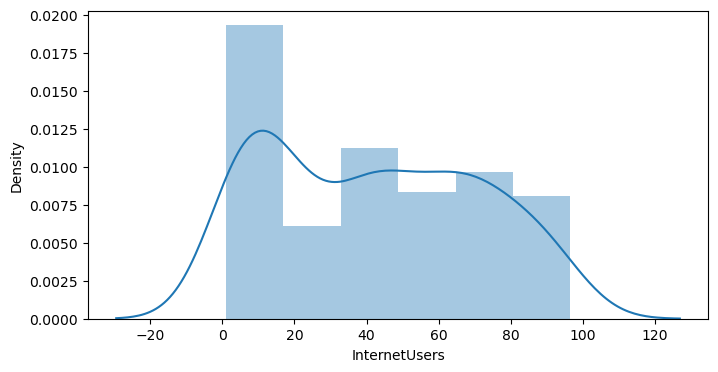

```python
Vis1= sns.distplot(gdp["InternetUsers"])
```

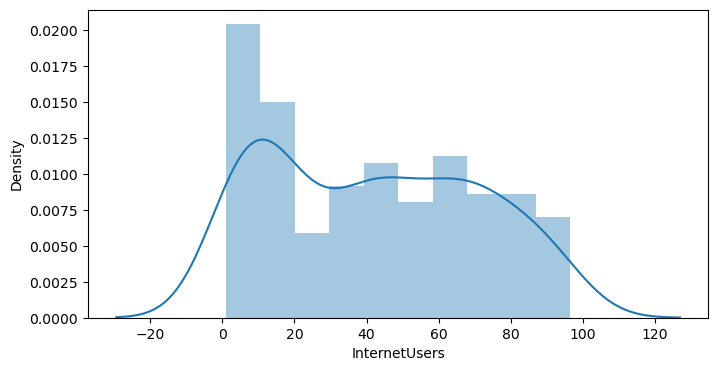

```python
Vis2= sns.distplot(gdp["InternetUsers"], bins=10)
```

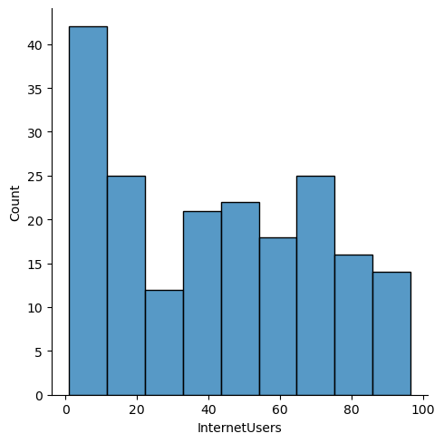

```python
Vis3= sns.displot(gdp["InternetUsers"])
```

## BOX PLOTS:

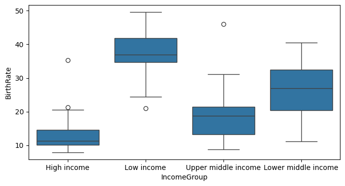

```python
vis4 = sns.boxplot(data = gdp, x="IncomeGroup", y='BirthRate')
```

# visualizing with seaborn

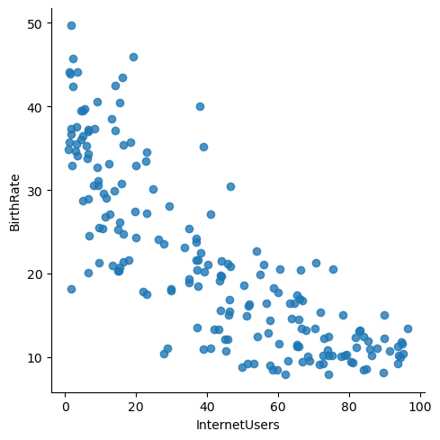

```python
vis5 = sns.lmplot(data = gdp,x = 'InternetUsers', y = 'BirthRate', fit_reg = False) #lm - linear model
```

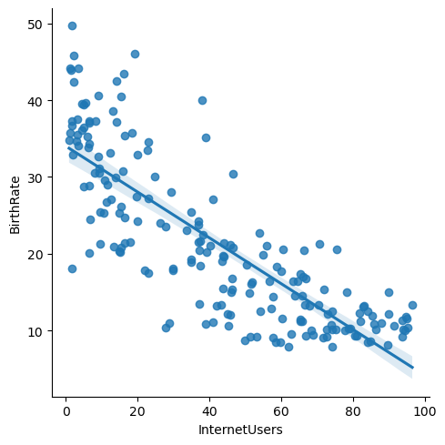

```python
vis6 = sns.lmplot(data = gdp,x = 'InternetUsers', y = 'BirthRate')
```

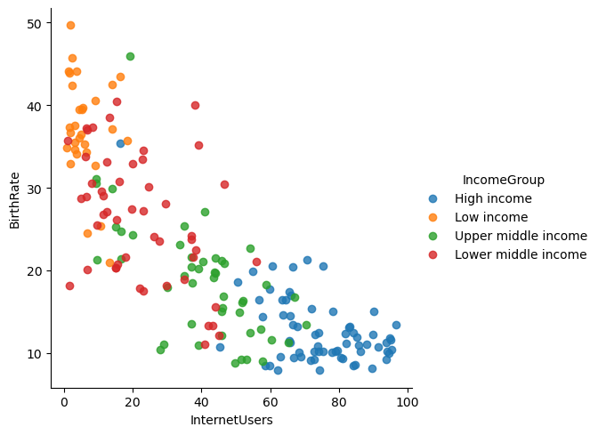

```python
vis7 = sns.lmplot(data = gdp,x = 'InternetUsers', y = 'BirthRate',
                  fit_reg = False,hue = 'IncomeGroup') #hue - parameter for color
```

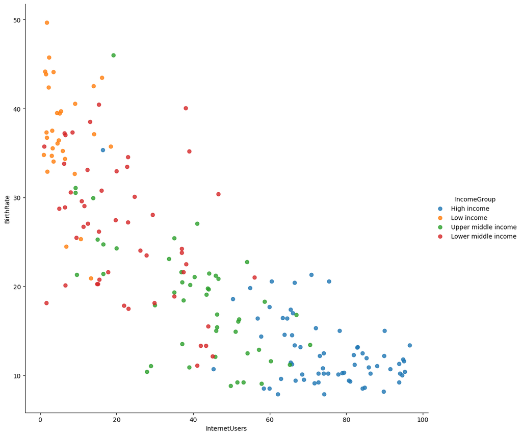

```python
vis8 = sns.lmplot(data = gdp,x = 'InternetUsers', y = 'BirthRate',
                  fit_reg = False,hue = 'IncomeGroup', height=10)
```